[figure not shown]

Project 1

Introduction

The data sets I have chosen are all related to the NBA. I thought it would be

very interesting if I were to gather data regarding past NBA Champions. I

found these data online through diﬀerent websites. I wanted to ﬁnd associations

regarding awards that were given that year in regard to who the champions

were. This information is interesting to me because I have always been a huge

basketball fan.

library(readxl)

library(dplyr)

##

##

## filter, lag

##

## intersect, setdiff, setequal, union

library(ggplot2)

library(knitr)

library(tidyverse)

## x dplyr::filter() masks stats::filter()

## x dplyr::lag() masks stats::lag()

NBA_Finals<-read_excel("NBA Finals.xlsx")

NBA_Awards<-read_excel("NBA Awards.xlsx")

NBA_Finals

## # A tibble: 62 x 7

## Year `NBA Champion` `Champ-Wins` `Champ-Losses` Loser `Loser-Wins`

## <dbl> <chr> <dbl> <dbl> <chr> <dbl>

## 1 1956 Philadelphia ~ 45 27 Fort~ 37

[figure not shown]

## 2 1957 Boston Celtics 44 28 St. ~ 34

## 3 1958 St. Louis Haw~ 41 31 Bost~ 49

## 4 1959 Boston Celtics 52 20 Minn~ 33

## 5 1960 Boston Celtics 59 16 St. ~ 46

## 6 1961 Boston Celtics 57 22 St. ~ 51

## 7 1962 Boston Celtics 60 20 Los ~ 54

## 8 1963 Boston Celtics 58 22 Los ~ 53

## 9 1964 Boston Celtics 59 21 San ~ 48

## 10 1965 Boston Celtics 62 18 Los ~ 49

## # ... with 52 more rows, and 1 more variable: `Loser-Losses` <dbl>

NBA_Awards

## # A tibble: 62 x 9

## Year `Western Champi~ `Eastern Champi~ Result `NBA Champion` `MVP Name`

## <dbl> <chr> <chr> <chr> <chr> <chr>

## 1 1956 Fort Wayne Pist~ Philadelphia Wa~ 1–4 Philadelphia ~ B. Pettit

## 2 1957 St. Louis Hawks Boston Celtics 3–4 Boston Celtics B. Cousy

## 3 1958 St. Louis Hawks Boston Celtics 4–2 St. Louis Haw~ B. Russell

## 4 1959 Minneapolis Lak~ Boston Celtics 0–4 Boston Celtics B. Pettit

## 5 1960 St. Louis Hawks Boston Celtics 3–4 Boston Celtics W. Chambe~

## 6 1961 St. Louis Hawks Boston Celtics 1–4 Boston Celtics B. Russell

## 7 1962 Los Angeles Lak~ Boston Celtics 3–4 Boston Celtics B. Russell

## 8 1963 Los Angeles Lak~ Boston Celtics 2–4 Boston Celtics B. Russell

## 9 1964 San Francisco W~ Boston Celtics 1–4 Boston Celtics O. Robert~

## 10 1965 Los Angeles Lak~ Boston Celtics 1–4 Boston Celtics B. Russell

## # ... with 52 more rows, and 3 more variables: `MVP Position` <chr>, `MVP

## # Team` <chr>, `MVP status` <chr>

NBA_Finals%>%pivot_wider(names_from="NBA Champion",values_from="Year")

## # A tibble: 62 x 23

## `Champ-Wins` `Champ-Losses` Loser `Loser-Wins` `Loser-Losses`

## <dbl> <dbl> <chr> <dbl> <dbl>

## 1 45 27 Fort~ 37 35

## 2 44 28 St. ~ 34 38

## 3 41 31 Bost~ 49 23

## 4 52 20 Minn~ 33 39

## 5 59 16 St. ~ 46 29

## 6 57 22 St. ~ 51 28

## 7 60 20 Los ~ 54 26

## 8 58 22 Los ~ 53 27

## 9 59 21 San ~ 48 32

## 10 62 18 Los ~ 49 31

## # ... with 52 more rows, and 18 more variables: `Philadelphia

## # Warriors` <dbl>, `Boston Celtics` <dbl>, `St. Louis Hawks` <dbl>,

## # `Philadelphia 76ers` <dbl>, `New York Knicks` <dbl>, `Milwaukee

## # Bucks` <dbl>, `Los Angeles Lakers` <dbl>, `Golden State

## # Warriors` <dbl>, `Portland Trail Blazers` <dbl>, `Washington

## # Bullets` <dbl>, `Seattle SuperSonics` <dbl>, `Detroit Pistons` <dbl>,

## # `Chicago Bulls` <dbl>, `Houston Rockets` <dbl>, `San Antonio

## # Spurs` <dbl>, `Miami Heat` <dbl>, `Dallas Mavericks` <dbl>, `Cleveland

## # Cavaliers` <dbl>

[figure not shown]

NBA_Finals %>% full_join(NBA_Awards)

## Joining, by = c("Year", "NBA Champion")

## # A tibble: 62 x 14

## Year `NBA Champion` `Champ-Wins` `Champ-Losses` Loser `Loser-Wins`

## <dbl> <chr> <dbl> <dbl> <chr> <dbl>

## 1 1956 Philadelphia ~ 45 27 Fort~ 37

## 2 1957 Boston Celtics 44 28 St. ~ 34

## 3 1958 St. Louis Haw~ 41 31 Bost~ 49

## 4 1959 Boston Celtics 52 20 Minn~ 33

## 5 1960 Boston Celtics 59 16 St. ~ 46

## 6 1961 Boston Celtics 57 22 St. ~ 51

## 7 1962 Boston Celtics 60 20 Los ~ 54

## 8 1963 Boston Celtics 58 22 Los ~ 53

## 9 1964 Boston Celtics 59 21 San ~ 48

## 10 1965 Boston Celtics 62 18 Los ~ 49

## # ... with 52 more rows, and 8 more variables: `Loser-Losses` <dbl>,

## # `Western Champion` <chr>, `Eastern Champion` <chr>, Result <chr>, `MVP

## # Name` <chr>, `MVP Position` <chr>, `MVP Team` <chr>, `MVP

## # status` <chr>

NBAfinalawards <- NBA_Finals %>% full_join(NBA_Awards)

## Joining, by = c("Year", "NBA Champion")

No variables in this join were dropped. I chose this join because I want all the variables to be included in

the joined dataset.

NBAfinalawards %>% filter(`MVP status`=="Champion")

## # A tibble: 23 x 14

## Year `NBA Champion` `Champ-Wins` `Champ-Losses` Loser `Loser-Wins`

## <dbl> <chr> <dbl> <dbl> <chr> <dbl>

## 1 1957 Boston Celtics 44 28 St. ~ 34

## 2 1961 Boston Celtics 57 22 St. ~ 51

## 3 1962 Boston Celtics 60 20 Los ~ 54

## 4 1963 Boston Celtics 58 22 Los ~ 53

## 5 1965 Boston Celtics 62 18 Los ~ 49

## 6 1967 Philadelphia ~ 68 13 San ~ 44

## 7 1970 New York Knic~ 60 22 Los ~ 46

## 8 1971 Milwaukee Buc~ 66 16 Balt~ 42

## 9 1980 Los Angeles L~ 60 22 Phil~ 59

## 10 1983 Philadelphia ~ 65 17 Los ~ 58

## # ... with 13 more rows, and 8 more variables: `Loser-Losses` <dbl>,

## # `Western Champion` <chr>, `Eastern Champion` <chr>, Result <chr>, `MVP

## # Name` <chr>, `MVP Position` <chr>, `MVP Team` <chr>, `MVP

## # status` <chr>

[figure not shown]

NBAfinalawards %>% arrange(`Champ-Wins`)

## # A tibble: 62 x 14

## Year `NBA Champion` `Champ-Wins` `Champ-Losses` Loser `Loser-Wins`

## <dbl> <chr> <dbl> <dbl> <chr> <dbl>

## 1 1999 San Antonio S~ 37 13 New ~ 27

## 2 1958 St. Louis Haw~ 41 31 Bost~ 49

## 3 1957 Boston Celtics 44 28 St. ~ 34

## 4 1978 Washington Bu~ 44 38 Seat~ 47

## 5 1956 Philadelphia ~ 45 27 Fort~ 37

## 6 2012 Miami Heat 46 20 Okla~ 48

## 7 1995 Houston Rocke~ 47 35 Orla~ 57

## 8 1969 Boston Celtics 48 34 Los ~ 55

## 9 1975 Golden State ~ 48 34 Wash~ 60

## 10 1977 Portland Trai~ 49 33 Phil~ 50

## # ... with 52 more rows, and 8 more variables: `Loser-Losses` <dbl>,

## # `Western Champion` <chr>, `Eastern Champion` <chr>, Result <chr>, `MVP

## # Name` <chr>, `MVP Position` <chr>, `MVP Team` <chr>, `MVP

## # status` <chr>

NBAfinalawards %>% select(Year,`NBA Champion`,`MVP Name`,`MVP Team`)

## # A tibble: 62 x 4

## Year `NBA Champion` `MVP Name` `MVP Team`

## <dbl> <chr> <chr> <chr>

## 1 1956 Philadelphia Warriors B. Pettit Saint Louis Hawks

## 2 1957 Boston Celtics B. Cousy Boston Celtics

## 3 1958 St. Louis Hawks B. Russell Boston Celtics

## 4 1959 Boston Celtics B. Pettit Saint Louis Hawks

## 5 1960 Boston Celtics W. Chamberlain Philadelphia Warriors

## 6 1961 Boston Celtics B. Russell Boston Celtics

## 7 1962 Boston Celtics B. Russell Boston Celtics

## 8 1963 Boston Celtics B. Russell Boston Celtics

## 9 1964 Boston Celtics O. Robertson Cincinnati Royals

## 10 1965 Boston Celtics B. Russell Boston Celtics

## # ... with 52 more rows

NBAfinalawards$`Champ-Wins` <- as.numeric(NBAfinalawards$`Champ-Wins`)

NBAfinalawards <- NBAfinalawards %>% mutate(champwinratio = `Champ-Wins`/ (`Champ-Wins` + `Champ-Losses`))

NBAfinalawards %>% summarize(mean(`Champ-Wins`))

## # A tibble: 1 x 1

## `mean(\`Champ-Wins\`)`

## <dbl>

## 1 58.1

NBAfinalawards %>% summarize(sd(`Champ-Wins`))

## # A tibble: 1 x 1

## `sd(\`Champ-Wins\`)`

## <dbl>

## 1 7.54

[figure not shown]

NBAfinalawards %>% summarize(max(`Champ-Wins`))

## # A tibble: 1 x 1

## `max(\`Champ-Wins\`)`

## <dbl>

## 1 72

NBAfinalawards %>% filter(`NBA Champion`== "Los Angeles Lakers") %>% summarize(mean(`Champ-Wins`))

## # A tibble: 1 x 1

## `mean(\`Champ-Wins\`)`

## <dbl>

## 1 61.6

NBAfinalawards %>% group_by(`MVP Team`) %>% summarize(median(champwinratio))

## # A tibble: 22 x 2

## `MVP Team` `median(champwinratio)`

## <chr> <dbl>

## 1 Baltimore Bullets 0.585

## 2 Boston Celtics 0.738

## 3 Buffalo Braves 0.585

## 4 Chicago Bulls 0.756

## 5 Cincinnati Royals 0.738

## 6 Cleveland Cavaliers 0.744

## 7 Dallas Mavericks 0.707

## 8 Golden State Warriors 0.756

## 9 Houston Rockets 0.695

## 10 Los Angeles Lakers 0.75

## # ... with 12 more rows

NBAfinalawards %>% group_by(`MVP Position`) %>% summarize(mean(champwinratio))

## # A tibble: 3 x 2

## `MVP Position` `mean(champwinratio)`

## <chr> <dbl>

## 1 Center 0.699

## 2 Forward 0.737

## 3 Guard 0.747

NBAfinalawards %>% group_by(`NBA Champion`,Loser) %>% summarize(median(champwinratio))

## # A tibble: 44 x 3

## # Groups: NBA Champion [18]

## `NBA Champion` Loser `median(champwinratio)`

## <chr> <chr> <dbl>

## 1 Boston Celtics Houston Rockets 0.787

## 2 Boston Celtics Los Angeles Lakers 0.738

## 3 Boston Celtics Milwaukee Bucks 0.683

## 4 Boston Celtics Minneapolis Lakers 0.722

[figure not shown]

## 5 Boston Celtics Phoenix Suns 0.659

## 6 Boston Celtics San Francisco Warriors 0.738

## 7 Boston Celtics St. Louis Hawks 0.722

## 8 Chicago Bulls Los Angeles Lakers 0.744

## 9 Chicago Bulls Phoenix Suns 0.695

## 10 Chicago Bulls Portland Trail Blazers 0.817

## # ... with 34 more rows

NBAfinalawards %>% summarize(max(`Loser-Wins`))

## # A tibble: 1 x 1

## `max(\`Loser-Wins\`)`

## <dbl>

## 1 73

NBAfinalawards %>% summarize(min(`Champ-Wins`))

## # A tibble: 1 x 1

## `min(\`Champ-Wins\`)`

## <dbl>

## 1 37

NBAfinalawards %>% filter(`MVP Name` == "S. Curry") %>% summarize(max(`Champ-Wins`))

## # A tibble: 1 x 1

## `max(\`Champ-Wins\`)`

## <dbl>

## 1 67

NBAfinalawards %>% filter(`MVP Name` == "S. Curry") %>% summarize(mean(`Champ-Wins`))

## # A tibble: 1 x 1

## `mean(\`Champ-Wins\`)`

## <dbl>

## 1 62

In the ﬁrst function, I found what mean number of regular season wins was for a NBA champion. In the

second function, I found out what the standard deviation of regular seaason wins was for NBA champion. In

the third function, I found out what the maximum number of regular season wins was for a NBA Champion.

In the fourth function, I found the mean number of wins for the Lakers whent they won a championship.

In the ﬁfth function, I found the median winratio for every MVP Team. In the sixth function, I found the

of wins for a championship team was 37.

df <- NBAfinalawards %>% select_if(is.numeric)

cor(df)

## Year Champ-Wins Champ-Losses Loser-Wins Loser-Losses

## Year 1.0000000 0.27295698 -0.20727994 0.43692275 -0.43748818

[figure not shown]

## Champ-Wins 0.2729570 1.00000000 -0.74422388 0.40434660 -0.05216915

## Champ-Losses -0.2072799 -0.74422388 1.00000000 0.02081767 0.06125185

## Loser-Wins 0.4369227 0.40434660 0.02081767 1.00000000 -0.78089921

## Loser-Losses -0.4374882 -0.05216915 0.06125185 -0.78089921 1.00000000

## champwinratio 0.2504473 0.87847182 -0.97163779 0.12823123 -0.06470612

## champwinratio

## Year 0.25044734

## Champ-Wins 0.87847182

## Champ-Losses -0.97163779

## Loser-Wins 0.12823123

## Loser-Losses -0.06470612

## champwinratio 1.00000000

tidycor <- cor(df) %>% as.data.frame()

head(tidycor)

## Year Champ-Wins Champ-Losses Loser-Wins Loser-Losses

## Year 1.0000000 0.27295698 -0.20727994 0.43692275 -0.43748818

## Champ-Wins 0.2729570 1.00000000 -0.74422388 0.40434660 -0.05216915

## Champ-Losses -0.2072799 -0.74422388 1.00000000 0.02081767 0.06125185

## Loser-Wins 0.4369227 0.40434660 0.02081767 1.00000000 -0.78089921

## Loser-Losses -0.4374882 -0.05216915 0.06125185 -0.78089921 1.00000000

## champwinratio 0.2504473 0.87847182 -0.97163779 0.12823123 -0.06470612

## champwinratio

## Year 0.25044734

## Champ-Wins 0.87847182

## Champ-Losses -0.97163779

## Loser-Wins 0.12823123

## Loser-Losses -0.06470612

## champwinratio 1.00000000

ggplot(NBAfinalawards, aes(`MVP Position`, champwinratio, color = `MVP status`)) + geom_point() + ggtitle("Status of MVPs")

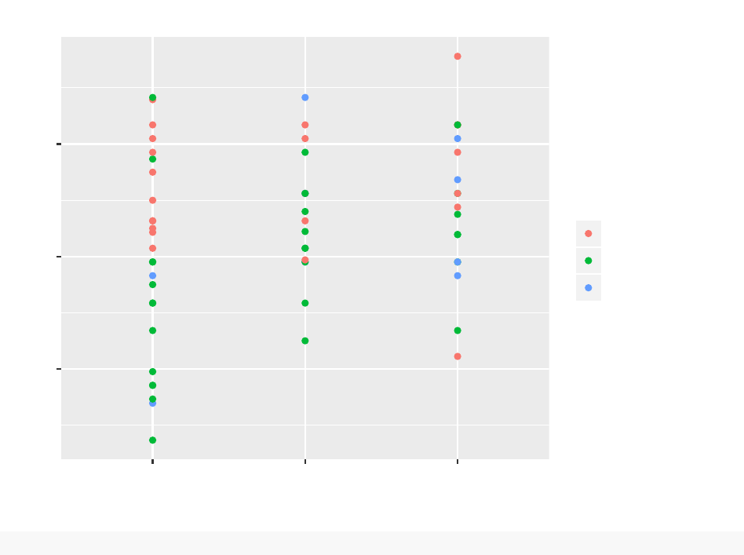

0.6

0.7

0.8

Center Forward Guard

MVP Position

champwinratio

MVP status

Champion

Not reached Final

Vice−Champion

Status of MVPs

ggplot(NBAfinalawards, aes(`Champ-Wins`,champwinratio, color = `MVP Position`)) + geom_bar(stat = "summary", fun.y = "mean")+ geom_errorbar(stat = "summary") + geom_point() + ggtitle("NBA Champions") + scale_x_log10()

## No summary function supplied, defaulting to `mean_se()

## Warning: Removed 31 rows containing missing values (geom_errorbar).

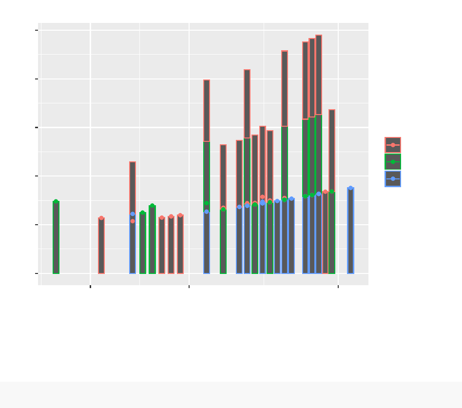

0.0

0.5

1.0

1.5

2.0

2.5

40 50 70

Champ−Wins

champwinratio

MVP Position

Center

Forward

Guard

NBA Champions

library(cluster)

pam1 <- NBAfinalawards %>% pam(k=3)

## Warning in data.matrix(x): NAs introduced by coercion

## Warning in data.matrix(x): NAs introduced by coercion

## Warning in data.matrix(x): NAs introduced by coercion

## Warning in data.matrix(x): NAs introduced by coercion

[figure not shown]

pam1

## Medoids:

## ID Year NBA Champion Champ-Wins Champ-Losses Loser Loser-Wins

## [1,] 9 1964 NA 59 21 NA 48

## [2,] 34 1989 NA 63 19 NA 57

## [3,] 50 2005 NA 59 23 NA 54

## Loser-Losses Western Champion Eastern Champion Result MVP Name

## [1,] 32 NA NA NA NA

## [2,] 25 NA NA NA NA

## [3,] 28 NA NA NA NA

## MVP Position MVP Team MVP status champwinratio

## [1,] NA NA NA 0.7375000

## [2,] NA NA NA 0.7682927

## [3,] NA NA NA 0.7195122

## Clustering vector:

## [1] 1 1 1 1 1 1 1 1 1 1 1 1 1 1 1 1 1 1 2 1 1 1 1 2 2 1 2 2 2 2 2 2 2 2 2

## [36] 2 2 2 2 3 2 2 2 3 2 3 3 3 3 3 3 3 3 3 3 3 3 3 3 3 3 3

## Objective function:

## build swap

## 20.55976 19.97377

##

## Available components:

## [1] "medoids" "id.med" "clustering" "objective" "isolation"

## [6] "clusinfo" "silinfo" "diss" "call" "data"

pamclust<-NBAfinalawards %>% mutate(cluster=as.factor(pam1$clustering))

pamclust %>% ggplot(aes(champwinratio,`Champ-Wins`,color=`MVP Position`)) + geom_point()

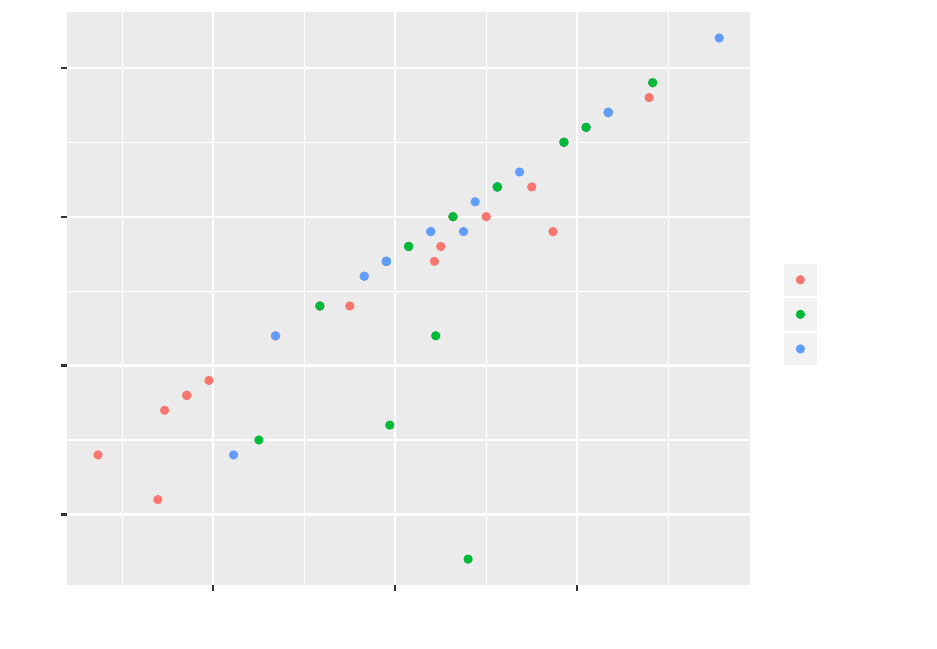

40

50

60

70

0.6 0.7 0.8

champwinratio

Champ−Wins

MVP Position

Center

Forward

Guard

The guard positions have the highest championship win ratios.